# Tarea 3 Modelos Lineales

## 4. Repita el item 2, pero esta vez seleccione las 4 variables que, según su criterio, tienen mejor poder predictivo. ¿Mejoran los resultados?

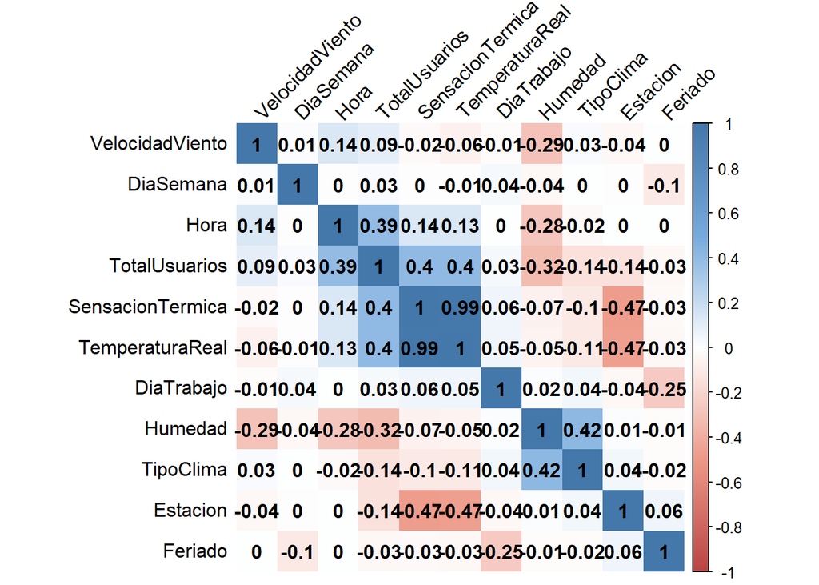

```r
library(corrplot)
matriz.correlacion<-cor(datos)


col <- colorRampPalette(c("#BB4444", "#EE9988", "#FFFFFF", "#77AADD", "#4477AA"))
corrplot(matriz.correlacion, method="shade", shade.col=NA, tl.col="black", tl.srt=45,
col=col(200), addCoef.col="black", order="AOE")
```

```r
library("ggplot2")
```

```r
#Selecciones Hora, Humedad, SensacionTermica, TemperaturaReal
modelo.knn <- train.knn(TotalUsuarios~., data = aprendizaje[,c(2,9,7,8,11)], kmax = floor(sqrt(n)) )

modelo.knn
```

```
Call:
kknn::train.kknn(formula = TotalUsuarios ~ ., data = aprendizaje[,     c(2, 9, 7, 8, 11)], kmax = floor(sqrt(n)))

Type of response variable: continuous
minimal mean absolute error: 67.90832
Minimal mean squared error: 10483.36
Best kernel: optimal
Best k: 11
```

```r
prediccion <- predict(modelo.knn, testing)

numero.predictoras <- 4

pre.knn <- indices.precision(testing$TotalUsuarios,prediccion$prediction,numero.predictoras)

pre.knn
```

```
$error.cuadratico
[1] 11707.34

$raiz.error.cuadratico
[1] 108.2784

$error.relativo
[1] 0.3932259

$correlacion
[1] 0.7925853
```

No mejoran los resultados, en su lugar empeoran pero no por mucho, lo cual es positivo ya que es un modelo con menos variables y más simple de interpretar.

## 4. Genere un Modelo de Regresión usando K vecinos más cercanos para cada uno de los siguientes núcleos: `rectangular`, `triangular`, `epanechnikov`, `biweight`, `triweight`, `cos`, `inv`, `gaussian` y `optimal` ¿Cuál produce los mejores resultados?

### Rectangular

```r
modelo.rectangular <- train.knn(TotalUsuarios~., data = aprendizaje, kernel = "rectangular")

prediccion <- predict(modelo.rectangular, testing)

pre.rectangular <- indices.precision(testing$TotalUsuarios ,prediccion$prediction,numero.predictoras)

pre.rectangular
```

```
$error.cuadratico
[1] 11787.44

$raiz.error.cuadratico
[1] 108.6482

$error.relativo
[1] 0.3960307

$correlacion
[1] 0.7921039
```

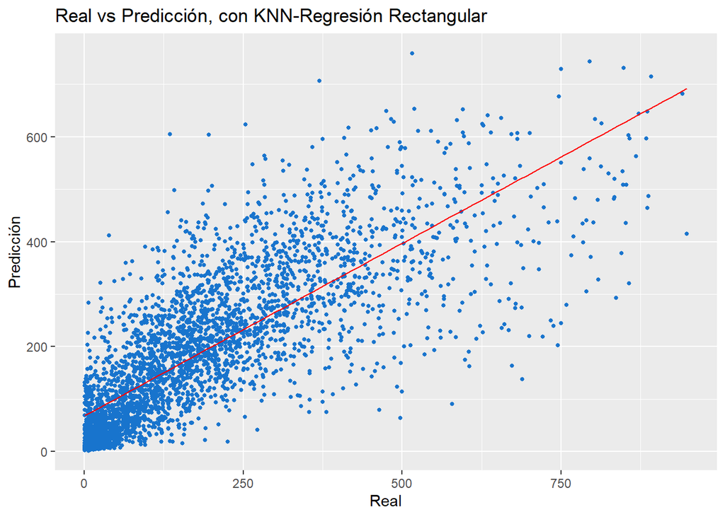

```r
g <- plot.real.prediccion(testing$TotalUsuarios, prediccion$prediction, modelo = "KNN-Regresión Rectangular")
g + geom_smooth(method = lm, size = 0.4, color = "red", se = FALSE)
```

### Triangular

```r
modelo.triangular <- train.knn(TotalUsuarios~., data = aprendizaje, kernel = "triangular")

prediccion <- predict(modelo.triangular, testing)

pre.triangular <- indices.precision(testing$TotalUsuarios ,prediccion$prediction,numero.predictoras)

pre.triangular
```

```
$error.cuadratico
[1] 10754.17

$raiz.error.cuadratico
[1] 103.777

$error.relativo
[1] 0.3746114

$correlacion
[1] 0.8115684
```

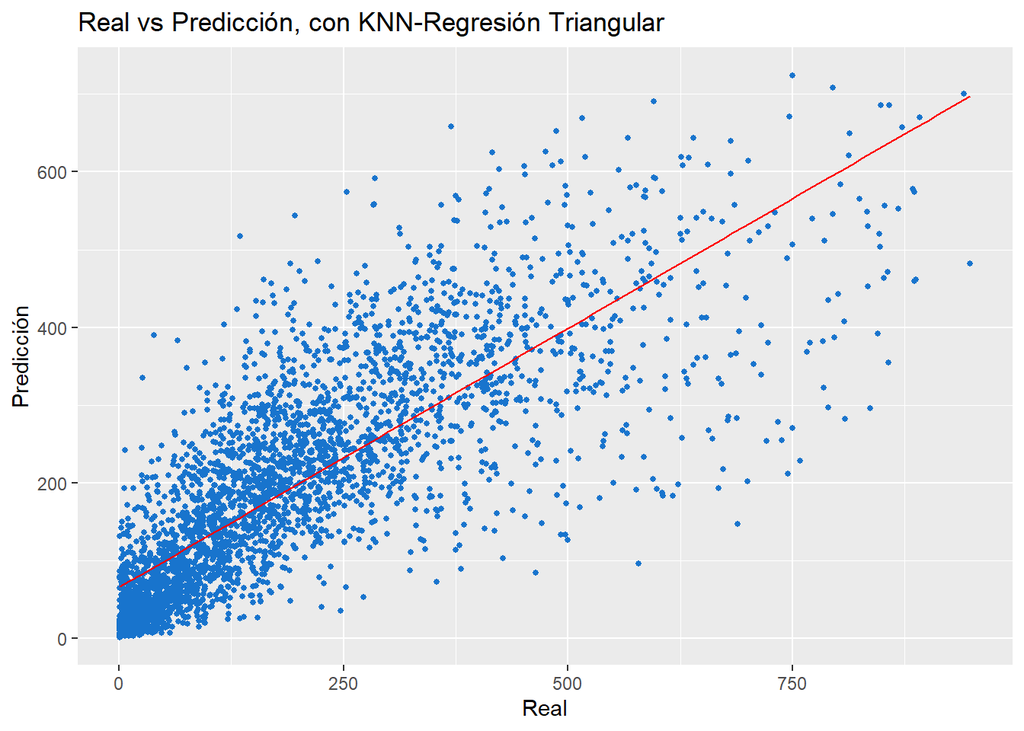

```r
g <- plot.real.prediccion(testing$TotalUsuarios, prediccion$prediction, modelo = "KNN-Regresión Triangular")
g + geom_smooth(method = lm, size = 0.4, color = "red", se = FALSE)
```

### Epanechnikov

```r
modelo.epanechnikov <- train.knn(TotalUsuarios~., data = aprendizaje, kernel = "epanechnikov")

prediccion <- predict(modelo.epanechnikov, testing)

pre.epanechnikov <- indices.precision(testing$TotalUsuarios ,prediccion$prediction,numero.predictoras)

pre.epanechnikov
```

```
$error.cuadratico
[1] 10894.07

$raiz.error.cuadratico
[1] 104.4498

$error.relativo
[1] 0.3766725

$correlacion
[1] 0.8089194
```

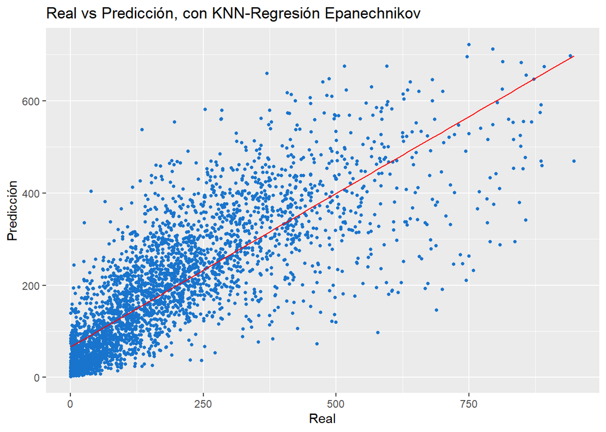

```r
g <- plot.real.prediccion(testing$TotalUsuarios, prediccion$prediction, modelo = "KNN-Regresión Epanechnikov")

g + geom_smooth(method = lm, size = 0.4, color = "red", se = FALSE)
```

### Biweight

```r
modelo.biweight <- train.knn(TotalUsuarios~., data = aprendizaje, kernel = "biweight")

prediccion <- predict(modelo.biweight, testing)

pre.biweight <- indices.precision(testing$TotalUsuarios ,prediccion$prediction,numero.predictoras)

pre.biweight
```

```
$error.cuadratico
[1] 10802.41

$raiz.error.cuadratico
[1] 104.0095

$error.relativo
[1] 0.3720706

$correlacion
[1] 0.8108634
```

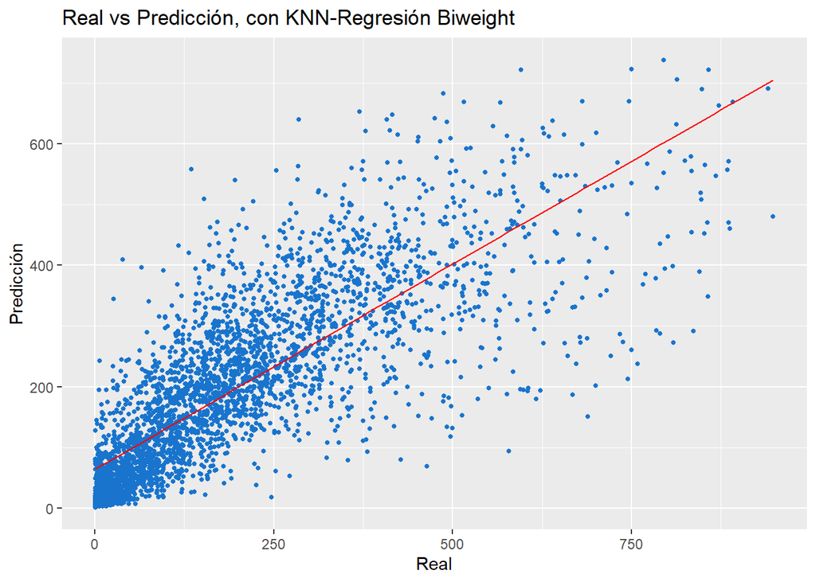

```r
g <- plot.real.prediccion(testing$TotalUsuarios, prediccion$prediction, modelo = "KNN-Regresión Biweight")
g + geom_smooth(method = lm, size = 0.4, color = "red", se = FALSE)
```

### Triweight

```r
modelo.triweight <- train.knn(TotalUsuarios~., data = aprendizaje, kernel = "triweight")

prediccion <- predict(modelo.triweight, testing)

pre.triweight <- indices.precision(testing$TotalUsuarios ,prediccion$prediction,numero.predictoras)

pre.triweight
```

```
$error.cuadratico
[1] 10999.82

$raiz.error.cuadratico
[1] 104.9555

$error.relativo
[1] 0.3690528

$correlacion
[1] 0.8084221
```

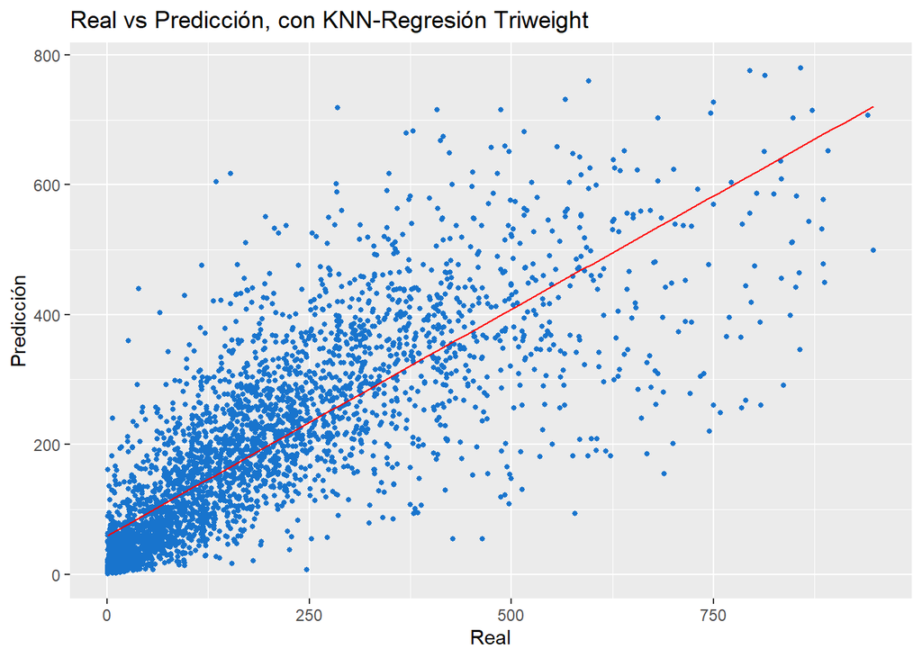

```r
g <- plot.real.prediccion(testing$TotalUsuarios, prediccion$prediction, modelo = "KNN-Regresión Triweight")
g + geom_smooth(method = lm, size = 0.4, color = "red", se = FALSE)
```

### Cos

```r
modelo.cos <- train.knn(TotalUsuarios~., data = aprendizaje, kernel = "cos")

prediccion <- predict(modelo.cos, testing)

pre.cos <- indices.precision(testing$TotalUsuarios ,prediccion$prediction,numero.predictoras)

pre.cos
```

```
$error.cuadratico
[1] 10836.98

$raiz.error.cuadratico
[1] 104.1757

$error.relativo
[1] 0.3748047

$correlacion
[1] 0.8100729
```

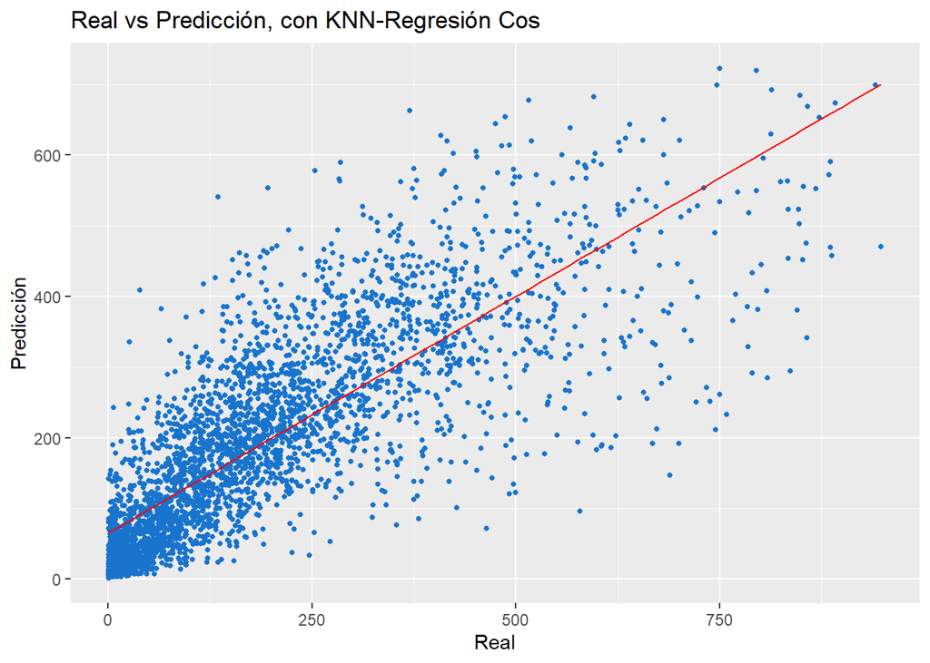

```r
g <- plot.real.prediccion(testing$TotalUsuarios, prediccion$prediction, modelo = "KNN-Regresión Cos")
g + geom_smooth(method = lm, size = 0.4, color = "red", se = FALSE)
```

### inv

```r
modelo.inv <- train.knn(TotalUsuarios~., data = aprendizaje, kernel = "inv")

prediccion <- predict(modelo.inv, testing)

pre.inv <- indices.precision(testing$TotalUsuarios ,prediccion$prediction,numero.predictoras)

pre.inv
```

```
$error.cuadratico
[1] 10939.11

$raiz.error.cuadratico
[1] 104.6655

$error.relativo
[1] 0.3785813

$correlacion
[1] 0.8081217
```

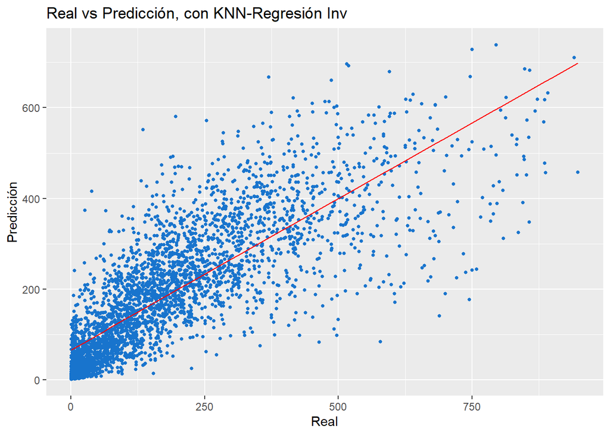

```r
g <- plot.real.prediccion(testing$TotalUsuarios, prediccion$prediction, modelo = "KNN-Regresión Inv")
g + geom_smooth(method = lm, size = 0.4, color = "red", se = FALSE)
```

### Gaussian

```r
modelo.gaussian <- train.knn(TotalUsuarios~., data = aprendizaje, kernel = "gaussian")

prediccion <- predict(modelo.gaussian, testing)

pre.gaussian <- indices.precision(testing$TotalUsuarios ,prediccion$prediction,numero.predictoras)

pre.gaussian
```

```
$error.cuadratico
[1] 11117.38

$raiz.error.cuadratico
[1] 105.5149

$error.relativo
[1] 0.3828038

$correlacion
[1] 0.8046721
```

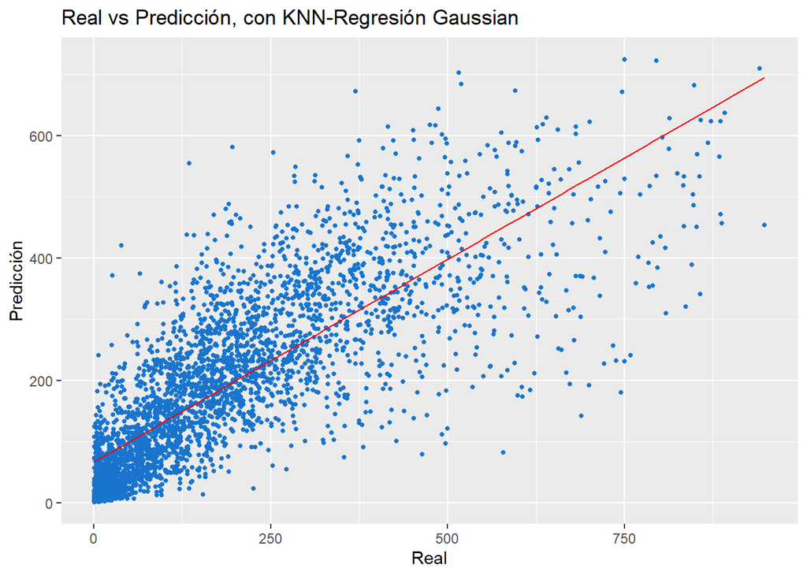

```r
g <- plot.real.prediccion(testing$TotalUsuarios, prediccion$prediction, modelo = "KNN-Regresión Gaussian")
g + geom_smooth(method = lm, size = 0.4, color = "red", se = FALSE)
```

### Optimal

```r
modelo.optimal <- train.knn(TotalUsuarios~., data = aprendizaje, kernel = "optimal")

prediccion <- predict(modelo.optimal, testing)

pre.optimal <- indices.precision(testing$TotalUsuarios ,prediccion$prediction,numero.predictoras)

pre.optimal
```

```
$error.cuadratico
[1] 10817.68

$raiz.error.cuadratico
[1] 104.083

$error.relativo
[1] 0.375654

$correlacion
[1] 0.8104585
```

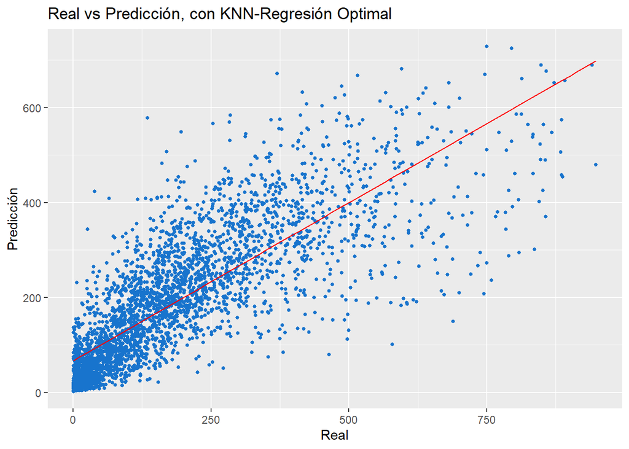

```r
g <- plot.real.prediccion(testing$TotalUsuarios, prediccion$prediction, modelo = "KNN-Regresión Optimal")
g + geom_smooth(method = lm, size = 0.4, color = "red", se = FALSE)
```

El mejor modelo es Triangular pues posee el menor error de todos los núcleos y la correlación más alta.